# Fitting very simple models with R-INLA

Sara Martino

Start by loading usefull libraries:

```r
library(INLA)
library(ggplot2)
library(patchwork)
library(spam)
# load some libraries to generate nice map plots
library(fields)
library(colorspace)
```

**Aim of this practical:** In this first practical we are going to look at some simple models

1. A Gaussian model with simulated data
2. A GLM model with random effects
3. A disease mapping model

we are going to learn:

- How to fit a simple model with the `inla()` function
- How to explore the results
- How to change the prior distributions
- How to get predictions for missing data points

# 1 Gaussian Example

In this practical we will use simulated Gaussian data to get familiar with the basic `R-INLA` functions. Moreover, we will see how to change the prior distributions both for the fixed effects $\beta_0$ and $\beta_1$ and for the hyperparameter $\tau = 1/\sigma^2$.

## 1.1 Simulate the data

We simulate data from the model

$$y_i\sim\mathcal{N}(\eta_i,0.1^2), \ i = 1,\dots,100$$
with
$$\eta_i = \beta_0 + \beta_1 x_i$$

where $\beta_0 = 2$,$\beta_1 = 0.5$ and the values of the covariate $x$ are generated from an Uniform(0,1) distribution. The simulated response and covariate data are then saved in a `data.frame` object.

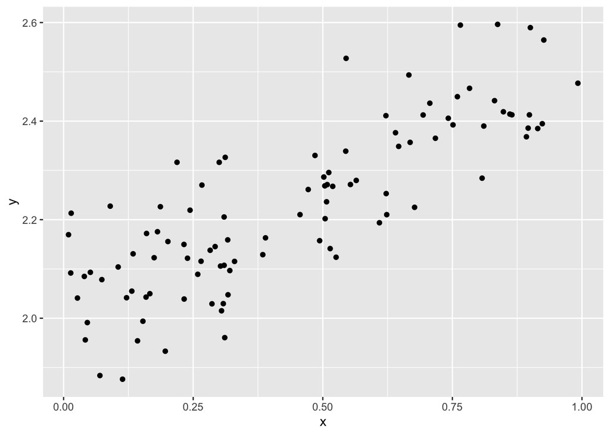

```r
set.seed(1234) #set the seed
n = 100        # number of data points
sigma = 0.1    # sd of the observation error
beta.0= 2      # intercept
beta.1 = 0.5   # coefficient for covariate x
x = runif(n)   # simulate covariate values
eta = beta.0 + beta.1*x  #compute linear predictor
y = rnorm(n,eta,sigma)   #simulate observartions
my.data = data.frame(y=y,x=x) #create a data frame
ggplot(data = my.data) + geom_point(aes(x,y)) #plot the simulated data
```

## 1.2 Model estimation

We now use the `inla()` function to estimate the parameters in the latent field $x = (\beta_0,\beta_1)$ and the hyperparameter $\theta = \{1/\sigma^2\}$.

```r
# define the formula
formula = y ~ x
# call the inla() function
output = inla(formula = formula,
              family = "gaussian",
              data  = my.data)
```

Notice that an intercept is always automatically included in the formula.

We can now loot at the results stored in the `output` object

```r
summary(output)
```

```
##
## Call:
##    c("inla.core(formula = formula, family = family, contrasts = contrasts,
##    ", " data = data, quantiles = quantiles, E = E, offset = offset, ", "
##    scale = scale, weights = weights, Ntrials = Ntrials, strata = strata,
##    ", " lp.scale = lp.scale, link.covariates = link.covariates, verbose =
##    verbose, ", " lincomb = lincomb, selection = selection, control.compute
##    = control.compute, ", " control.predictor = control.predictor,
##    control.family = control.family, ", " control.inla = control.inla,
##    control.fixed = control.fixed, ", " control.mode = control.mode,
##    control.expert = control.expert, ", " control.hazard = control.hazard,
##    control.lincomb = control.lincomb, ", " control.update =
##    control.update, control.lp.scale = control.lp.scale, ", "
##    control.pardiso = control.pardiso, only.hyperparam = only.hyperparam,
##    ", " inla.call = inla.call, inla.arg = inla.arg, num.threads =
##    num.threads, ", " blas.num.threads = blas.num.threads, keep = keep,
##    working.directory = working.directory, ", " silent = silent, inla.mode
##    = inla.mode, safe = FALSE, debug = debug, ", " .parent.frame =
##    .parent.frame)")
## Time used:
##     Pre = 4.1, Running = 6.76, Post = 0.0808, Total = 10.9
## Fixed effects:
##              mean    sd 0.025quant 0.5quant 0.975quant  mode kld
## (Intercept) 2.010 0.018      1.975    2.010      2.045 2.010   0
## x           0.496 0.034      0.428    0.496      0.563 0.496   0
##
## Model hyperparameters:
##                                           mean    sd 0.025quant 0.5quant
## Precision for the Gaussian observations 111.79 15.81      83.00   111.05
##                                         0.975quant   mode
## Precision for the Gaussian observations     144.87 109.56
##
## Marginal log-Likelihood:  77.14
##  is computed
## Posterior summaries for the linear predictor and the fitted values are computed
## (Posterior marginals needs also 'control.compute=list(return.marginals.predictor=TRUE)')
```

### 1.2.1 Posterior marginals for the fixed effects

We can then look at the marginals for $\beta_0$

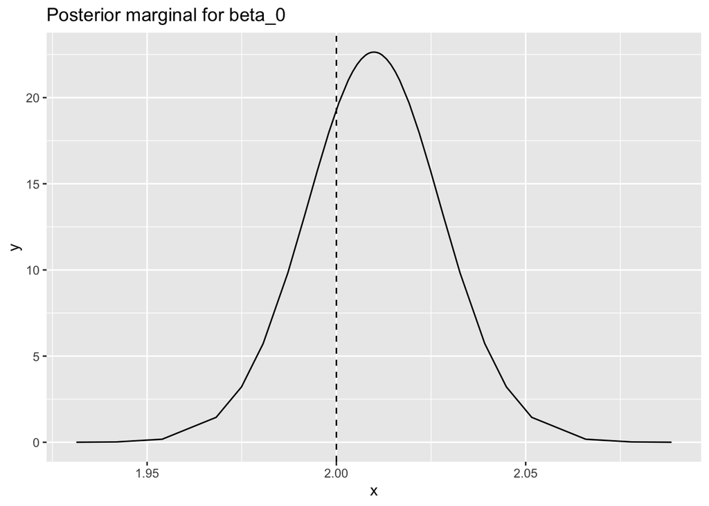

```r
# extract the marginal of interest
beta0 = output$marginals.fixed$`(Intercept)`
ggplot() +
  geom_line(data = data.frame(beta0),aes(x,y)) +
  geom_vline(xintercept = beta.0, lty  = "dashed")+
  ggtitle("Posterior marginal for beta_0")
```

**Exercise 1:** Plot the posterior marginal for $\beta_1$ and Use the function `inla.zmarginal()` to compute a summary of the posterior for the coefficient $\beta_1$.

Here you find a solution.

```r
beta1 = ???
p2 = ggplot() +
  geom_line(data = data.frame(beta1), aes(x,y)) +
  geom_vline(xintercept  = beta.1, lty  = "dashed")+
  ggtitle("Posterior marginal for beta_1")
```

### 1.2.2 Posterior marginals for the hyperparameter

**Exercise 2:** Compute the posterior marginal for the sd of the observation error $\pi(\sigma^2|\bf{y})$  
Here you find the solution.

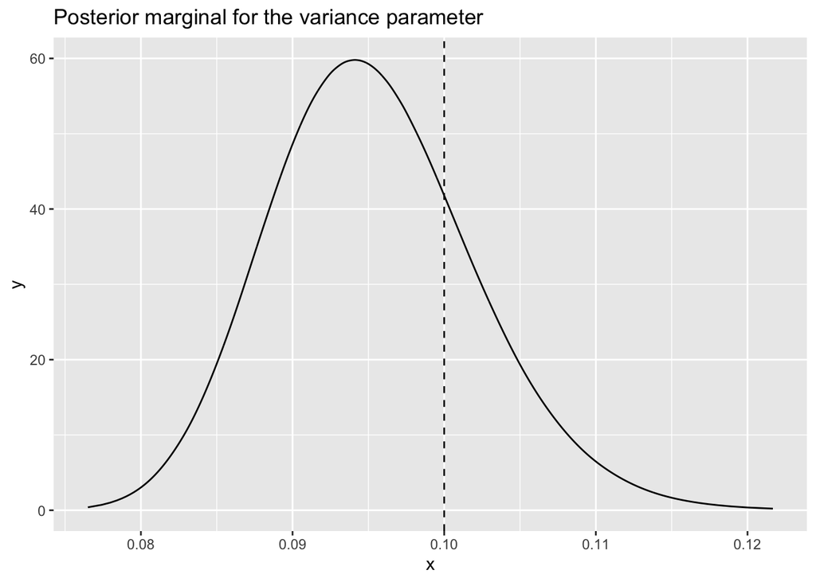

```r
# extract the posterior for the precision parameter
tau = ??

#Use   `inla.tmarginal()` to compute the marginal for sigma^2
sigma2 = inla.tmarginal(fun = ??,
                        marginal = tau)

ggplot() + geom_line(data = data.frame(sigma2), aes(x,y)) +
  geom_vline(xintercept = sigma, lty = "dashed") +
  ggtitle("Posterior marginal for the variance parameter")
```

## 1.3 Changing the prior for the hyperparameter $\tau = 1/\sigma^2$

The default prior in `R-INLA` for the response precision $\tau = 1/\sigma^2$ is a noninformative logGamma prior defined on the logarithm of the precision (internal scale). As it can be seen from the following shot

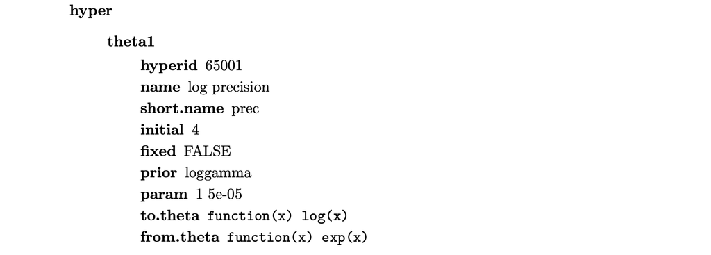

You can get the full documentation about how the Gaussian likelihood (or any other likelihood) is implemented in `INLA` as

```r
inla.doc("gaussian")
```

The default prior distribution is then:
$$\log(\tau)\sim\text{logGamma}(1,5e−05)$$
This is equivalent to assuming a Gamma prior on the precision, ie
$$\tau\sim\text{Gamma}(1,5e−05)$$

Since we are dealing with a parameter in the *likelihood* part of the model, it is possible to change its prior using the `control.family` option of the `inla()` function. For example if we want to specify a standard Normal(0,1) prior on the logarithm of the precision we will type:

```r
output3 = inla(formula,
               family="gaussian",
               data=my.data,
                    control.family=list(hyper=list(
                      prec=list(prior="gaussian",param=c(0,1)))))
```

```r
output3 = inla(formula,
               family="gaussian",
               data=my.data,
                    control.family=???)
```

# 2 A GLM with random effects

We are now going to fit GLM model with a random effect. Load the data `Seeds`

```r
data(Seeds)
```

This data concerns the proportion of seeds that germinated on each of 21 plates arranged according to a 2 by 2 factorial layout by seed and type of root extract. The data are shown below:

```
##    r  n x1 x2 plate
## 1 10 39  0  0     1
## 2 23 62  0  0     2
## 3 23 81  0  0     3
## 4 26 51  0  0     4
## 5 17 39  0  0     5
## 6  5  6  0  1     6
```

where $r_i$ and $n_i$ are the number of germinated and the total number of seeds on the $i$ th plate, $i =1,...,N$. The model is essentially a random effects logistic, allowing for over-dispersion. If $p_i$ is the probability of germination on the $i$ th plate, we assume
$$\begin{aligned}
r_i &\sim \text{Binomial}(p_i, n_i )\\
\text{logit}(p_i ) &= a_0 + a_1 x _{1i} + a_2 x_{2i} + \epsilon_i
\end{aligned}$$

where $x_{1i}$ , $x_{2i}$ are the seed type and root extract of the $i$ th plate.

**Exercise 4:** Fit the above model in R-INLA and check the summary of the result. Solution

1. Remember that all random effects are defined through the `f()` function!
2. Note that since the likelihood is binomial we also need to specify the number of trials. This is done in the `inla()` argument `N`.

```r
# write the formula
formula = r ~  ??
# run inla
out = inla(formula,
           data = Seeds,
           N = n,
           family = "binomial")
# get the summary of the result
 ???
```

**Exercise 5:** Plot the marginal posteriors for $a_0$ and $a_1$. Plot also the posterior means and a 95% CI for the random effect Solution

```r
## extract the posterior margianls for
## a0 and a1
a0 = ???
p1 = ggplot(data = data.frame(a0)) + geom_line(aes(x,y))
a1 = ???
p2 = ggplot(data = data.frame(a1)) + geom_line(aes(x,y))
p1+p2
```

The summaries for a random effect can be obtained by looking at `result$summary.random$NAME_OF_THE RANDOM_EFFECT`. So in our case:

```r
## plot posterior mean and a 95% CI for the random effect
rand = out$summary.random$plate
ggplot(data = rand) +
  geom_line(aes(x = ID, y = mean)) +
  geom_ribbon(aes(x = ID,
                  ymin = `0.025quant`,
                  ymax = `0.975quant`), alpha = 0.5)
```

# 3 Disease Mapping

This time we are going to work with a disease mapping (DM) model.

We consider data on the total Larynx cancer mortality in $544$ districts of Germany between 1986 and 1990.

This dataset is typical of many simple spatial examples and has the following properties: * Data $Y$ is given as the total number of counts in fixed areas across the spatial domain of interest

- We know which areas neighbor each other
- There is a covariate $x$ information regarding smoking consumption that is also spatial

We will use the standard Poisson likelihood to model the counts
$$y_i \mid \eta_i\sim Po\left(E_i \exp(\eta_i)\right),$$

where $E_i$ is the ``population at risk’’ in region $i$. Using a different $E_i$ in each region can help account for spatial heterogeneity in the underlying population.

The goal of this exercise is to fit several models without and with covariate information. In a later exercise we will compare the different model formulations.

The dataset is available in the `INLA` package and a plotting function for the Germany map is available in the `spam` function. The data can be loaded as follows:

```r
data(Germany)
str(Germany)    # see structure of data
```

```
## 'data.frame':    544 obs. of  4 variables:
##  $ region: num  1 2 3 4 5 6 7 8 9 10 ...
##  $ E     : num  7.97 22.84 22.09 7.92 13.14 ...
##  $ Y     : int  8 22 19 3 14 9 10 18 22 5 ...
##  $ x     : int  56 65 50 63 65 51 50 41 50 45 ...
```

and a map can be generated as:

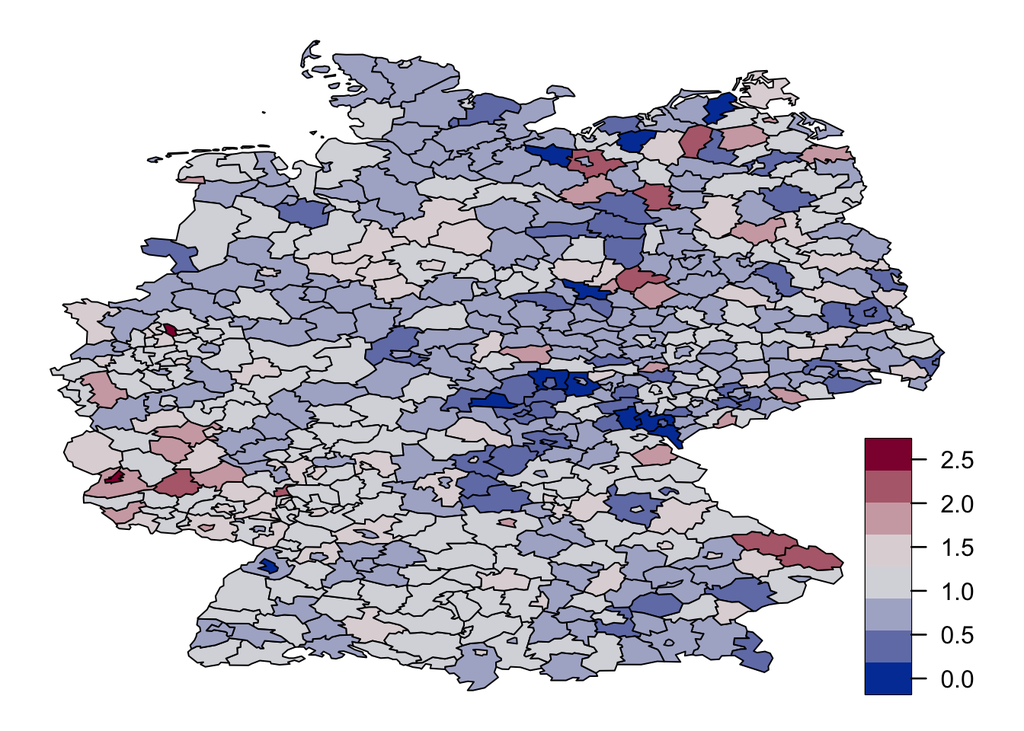

```r
col <- diverge_hcl(8)      # blue - red
# use a function provided by spam to plot the map together with the mortality rates
germany.plot(Germany$Y/Germany$E, col=col, legend=TRUE)
```

### 3.0.1 Fitting the model

We start by considering a classical disease mapping model containing an intercept $\mu$, a spatial structure effect $\bf{u}$ following the Besag model and an unstructured effect $\bf{v}$. This model is also known as BYM model according to the authors who proposed it: Besag, York and Mollie.

The log relative risk, $\bf{\eta} = (\eta_1, \dots, \eta_n)^T$, is thus decomposed into
$$\bf{\eta} = \mu + \bf{u} + \bf{v}.$$
Component ${\bf u} = (u_1, \ldots, u_n)^T$ is spatially structured with smoothing parameter $\kappa_u$. Component ${\bf v} = (v_1, \ldots, v_n)^T$ is unstructured white-noise with precision parameter $\kappa_v$, i.e. $\bf{v} \sim \mathcal{N}(0, \kappa_v^{-1}I)$.

The precision terms $\kappa_v$ and $\kappa_u$ are assigned the default gamma prior distributions of INLA
$$\begin{aligned}
\kappa_u & \sim \textrm{Gamma}( \alpha_u, \beta_u ), \\
\kappa_v & \sim \textrm{Gamma}( \alpha_v, \beta_v ).
\end{aligned}$$

where $\textrm{Gamma}(\alpha, \beta)$ denotes the gamma density with shape parameter $\alpha$ and rate parameter $\beta$. The default values are $\alpha_u = \alpha_v = 1$ and $\beta_u = \beta_v = 0.00005$.

This model can be fit in INLA using:

```r
## load the neighbourhood file
g = system.file("demodata/germany.graph", package="INLA")
## just make a duplicated column
Germany = cbind(Germany,region.struct=Germany$region)

# standard BYM model (without covariates)
formula = Y ~ f(region.struct, model="besag", graph=g) +
               f(region, model="iid")

result  =  inla(formula,
                family="poisson",
                data=Germany,
                E=E,
                control.compute = list(return.marginals.predictor    = TRUE,
                                       config = TRUE),
                control.predictor=list(compute=TRUE))
```

We include the option `control.predictor=list(compute=TRUE)` and `control.compute = list(return.marginals.predictor = TRUE)` in the `inla`-function to obtain also posterior marginals for the linear predictor and the linear predictor transformed to the data scale.

We also include the option `control.compute = list(config = TRUE)` as we later want to sample from the fitted model.

**Exercise 6:** Fit the model and inspect the posterior marginals.

**Exercise 7:** Use the function `germany.plot` to plot the median of $\exp(\bf{\eta})$. Generate a similar plot but showing $\exp(\bf{u})$. How do you interpret the plots? Solution

**Exercise 8:** We want to evaluate the proportion of the variance explained by the spatially structured component $\bf{u}$:
$$\text{frac}_{\text{spatial}} = \frac{\sigma^2_u}{\sigma^2_v+\sigma^2_u}=
\frac{\tau_v}{\tau_v+\tau_u}$$
where $\tau_v = 1/\sigma^2_v$ and $\tau_u = 1/\sigma^2_u$.

To do so we can use the `inla.hyperpar.sample()` function which generates samples from $\tilde{\pi}(\theta|y)$:

```r
hyper = inla.hyperpar.sample(n = 1000, result)
colnames(hyper)
```

```
## [1] "Precision for region.struct" "Precision for region"
```

Write a function that computes the quantity of interest $\text{frac}_{\text{spatial}}$ and comments on the results. Solution

**Exercise 9 :** Next we would like to include the covariate $\mathbf{x}$ into the model for larynx cancer as a linear effect. Extend the INLA code provided above and inspect the summary statistics to see how large the effect of smoking is. Solution

**Exercise 10:** Instead of assuming a linear effect, include the covariate as a non-linear effect using ar random walk of second order (`rw2`). You can use the default prior parameters of INLA for the gamma prior of the corresponding precision parameter. Plot the posterior median within $95\%$ credible intervals of $\bf{x}$. Based on this plot, what do you think is a linear or non-linear effect better suited?Solution

## 3.1 Prediction in an unobserved area

We now pretend that the observed data are missing in one of the regions and want to predict the expected count for that region.

```r
ind = 35
Germany_pred = Germany
Germany_pred$Y[ind] = NA
```

**Exercise 11:** Fit the model again using the new dataset. Use the version where smoking is included as a linear covariate.

```r
## 2. Add smoking as a linear covariate to the larynx cancer data

formulaLC1 = Y ~ ??

resultLC1  =  inla(formulaLC1, family="poisson", data=Germany_pred,
                   E=E,
                  control.compute = list(config = TRUE,
                           return.marginals.predictor=TRUE),
                  control.predictor=list(compute=TRUE,
                                       link = 1))
```

Notice that we have added here the options:

- `control.compute = list(config = TRUE,return.marginals.predictor=TRUE)`: to tell `inla()` to return the marginals for the fitted value $\exp(\eta)$ and to have the possibility to sample from the fitted model
- `control.predictor=list(compute=TRUE,link = 1)`: to tell `inla()` to compute the posterior marginals for the linear predictor $\eta$ and to inform it about this link function to use (see `?control.predictor`)

**Exercise 12:** Plot the posterior marginal for $\exp(\eta)$ for region 35 Solution

**Exercise 13:** We want to generate predictions for the counts in region 35. To do this we first need to find the posterior for the mean of the Poisson distribution in the region of interest $\lambda = E\exp(\eta)$. We can do it using samples:

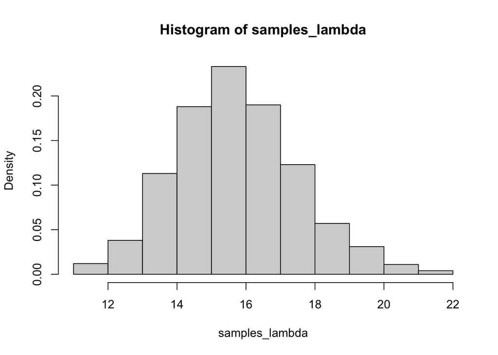

```r
nsamples = 1000
lambda_dens = resultLC1$marginals.fitted.values[[ind]]
samples_lambda = inla.rmarginal(1000, lambda_dens)*Germany$E[ind]
hist(samples_lambda, freq = F)
```

This is not the prediction density! We have obtained an estimate for $\pi(\lambda|y_1,\dots,y_n)$ but what we want is $\pi(y_{new}|y_1,\dots,y_n)$. Can you compute such prediction density? How does it look when compared to the histogram above? Solution

# 4 Solutions

## 4.1 Exercise 1

```r
# to extract the postrior marginal for beta_1
beta1 = output$marginals.fixed$x
# to compute posterior summaries
inla.zmarginal(beta1)
```

## 4.2 Exercise 2

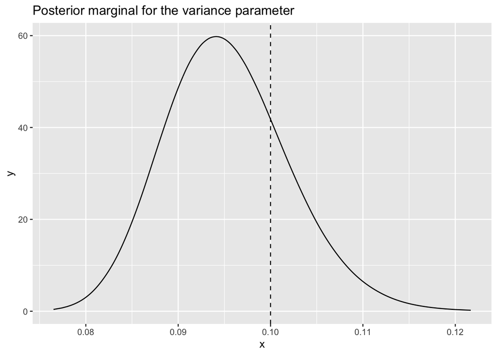

```r
# extract the posterior for the precision parameter
tau = output$marginals.hyperpar$`Precision for the Gaussian observations`

#Use   `inla.tmarginal()` to compute the marginal for sigma^2
sigma2 = inla.tmarginal(fun = function(x) 1/sqrt(x),
                        marginal = tau)

ggplot() + geom_line(data = data.frame(sigma2), aes(x,y)) +
  geom_vline(xintercept = sigma, lty = "dashed") +
  ggtitle("Posterior marginal for the variance parameter")
```

## 4.3 Exercise 3

```r
output3 = inla(formula,
               family="gaussian",
               data=my.data,
                    control.family=list(hyper=list(
                      prec=list(prior="loggamma",param=c(0,0.01)))))
```

## 4.4 Exercise 4

```r
# write the formula
formula = r ~  x1 + x2 + f(plate, model= "iid")
# run inla
out = inla(formula,
           data = Seeds,
           N = n,
           family = "binomial")
# get the summary of the result
summary(out)
```

## 4.5 Exercise 5

```r
## extract the posterior margianls for
## a0 and a1
a0 = out$marginals.fixed$`(Intercept)`
p1 = ggplot(data = data.frame(a0)) + geom_line(aes(x,y))
a1 = out$marginals.fixed$x1
p2 = ggplot(data = data.frame(a1)) + geom_line(aes(x,y))
p1+p2

## plot posterior mean and a 95% CI for the random effect
rand = out$summary.random$plate
ggplot(data = rand) +
  geom_line(aes(x = ID, y = mean)) +
  geom_ribbon(aes(x = ID,
                  ymin = `0.025quant`,
                  ymax = `0.975quant`), alpha = 0.5)
```

## 4.6 Exercise 7

```r
par(mfrow = c(1,2))
germany.plot(result$summary.fitted.values$"0.5quant", col=col, legend=TRUE)
germany.plot(exp(result$summary.random$region.struct$"0.5quant"), col=col, legend=TRUE)
```

The plots are very similar, meaning that the unstructured part of the model does not contribute much to the fitted value.

## 4.7 Exercise 8

```r
frac_spatial <- hyper[,2] / (hyper[,1]+hyper[,2])
hist(frac_spatial, n = 50, freq = F)
mean(frac_spatial)
```

The posterior mean of $\text{frac}_{\text{spatial}}$ is around 0.99 which means that most of the variability is explained from the spatial effect. This confirms the impression we had from the previous exercise.

## 4.8 Exercise 9

```r
## 2. Add smoking as a linear covariate to the larynx cancer data

formulaLC = Y ~ f(region.struct, model="besag", graph=g) +
  f(region, model="iid") + x

resultLC  =  inla(formulaLC, family="poisson", data=Germany, E=E,
                control.predictor=list(compute=TRUE))

# check summary statistics => slight positive effect of smoking
summary(resultLC)
```

## 4.9 Exercise 10

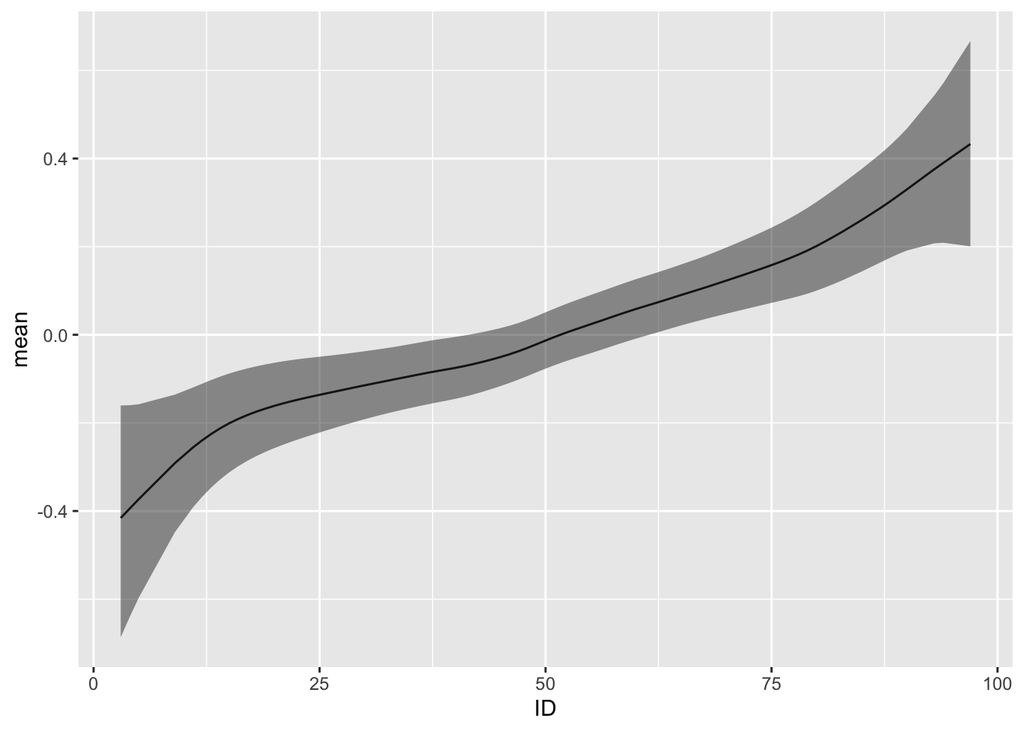

```r
## 3. Add smoking as a non-linear effect, here a RW2

formulaRW2 = Y ~ f(region.struct, model="besag", graph=g) +
  f(region, model="iid") + f(x, model="rw2")

resultRW2  =  inla(formulaRW2, family="poisson", data=Germany, E=E,
                  control.predictor=list(compute=TRUE))

# plot median within 95% CI for smoking


ggplot(data = resultRW2$summary.random$x ) + geom_line(aes(ID, mean)) +
  geom_ribbon(aes(ID, ymin = `0.025quant`, ymax = `0.975quant`), alpha = 0.5)
```

Based on this plot we might think actually that a linear effects is plausible However, since the 95CI is a point-wise and not simultaneous, we can not say this for sure. We have to look at model choice criteria.

## 4.10 Exercise 12

```r
plot(resultLC1$marginals.fitted.values[[35]])
```

## 4.11 Exercise 13

```r
predDist = rpois(1000, lambda = samples_lambda)

ggplot() + geom_density(data = data.frame(predDist = predDist), aes(predDist))+ geom_density(data = data.frame(samples_lambda = samples_lambda), aes(samples_lambda), color = "red") +
  geom_vline(xintercept = Germany$Y[ind])
```